# Measures of Central Tendency (Mean variables)

## Measures of Central Tendency

**Mean value** is one of the most important generalizing characteristics of statistics.

In average values individual differences of units of the population, caused by random circumstances, are extinguished, and common and regular features, peculiar to the whole population as a whole, are expressed.

Individual values of a feature (variants), from which the average value is calculated, should be of the same type, i.e. they should characterize homogeneous phenomena and have the same units of measurement.

## Ratio of mean

The mean is a generalizing indicator characterizing the typical level of a phenomenon. Initial ratio of mean:
$$IRM = \frac{Cumulative\:value\:value\:or\:volume\:volume\:average}{Number\:units\:or\:volume\:volume\:population}$$

In each specific case, the average value has a certain, socio-economic content, conditioned by the nature of the object under study.

For example: The average salary of the first employee is determined by dividing the labor remuneration fund by the number of employees. The average size of a deposit in a bank is determined by dividing the sum of all deposits.

## Generalized and structural means

In statistics, **Generalized and structural means** are calculated.

The general formula for generalized mean values is as follows:

$$\overline{x} = \sqrt[m]{ \frac{\sum{x^m_i f_i } }{\sum f_i} }$$
In this formula:

- $x_i$ - individual value of the feature (variants);
- $ƒ_i$ - corresponding frequencies (frequencies);
- $m$ - degree index.

The following **types of generalized mean** are distinguished :

1. When m = 1, $\rightarrow$ **arithmetic mean**.
2. When m = -1 $\rightarrow$ **harmonic mean**.
3. When m = 0 $\rightarrow$ **geometric mean**.
4. When m = 2 $\rightarrow$ **quadratic mean**.
5. When m = 3 $\rightarrow$ **cubic mean**.

The choice of formula for calculating the mean depends on the available background information.

## Arithmetic mean

Calculate **simple and weighted arithmetic mean**.

**The formula for simple** is as follows:
$$\overline{x} = \frac{x_1 + ... + x_n}{n} = \frac{\sum x_i}{n}$$

This formula is used when the initial data are not grouped (not formed into groups based on some attribute) and each unit of the population corresponds to a certain value of the attribute, or when all frequencies (frequencies) are equal to each other.

The **Formula** for the arithmetic **weighted** mean is as following:
$$\overline{x} = \frac{x_1f_1 + ... + x_nf_n}{f_1 + ... + f_n} = \frac{\sum x_i f_i}{\sum f_i}$$
This formula is used when the initial data are grouped, and each group of population units corresponds to a certain value of a feature (variant).

Example: A grouping of State Duma deputies by age is given:

| **Age of the deputy (full years) (x)** | **Number of deputies (number of people) (ƒ)** | **Interval midpoints (x)** | **xƒ** |
| --- | --- | --- | --- |
| 20-29 | 1 | 24,5 | 24,5 |
| 30-39 | 16 | 34,5 | 552 |
| 40-49 | 28 | 44,5 | 1246 |
| 50-59 | 30 | 54,5 | 1635 |
| 60-69 | 7 | 64,5 | 451,5 |
| **Total:** | **82** |  | **3909** |

To calculate the arithmetic mean in an interval variation series, you need to:

1. Close the available open intervals of grouping.
2. Find the midpoints of each interval, i.e. bring the interval series to a discrete form.
3. Find the product of the midpoints of the intervals by the corresponding frequencies (frequencies).

Average age of deputies of this faction:
$$\overline{x} = \frac{\sum x_i f_i}{\sum f_i} = \frac{3909}{82} = 47,7 (years)$$

## Mathematical properties of the arithmetic mean

1. The arithmetic mean of a constant quantity is equal to that same constant quantity.
2. The sum of deviations of individual values of a trait from the mean is 0.
   $$\sum x_i - \overline{x} = 0$$
3. The sum of products of individual values of the trait on the corresponding frequencies (frequencies) is equal to the product of the arithmetic mean on the sum of frequencies (frequencies).
   $$\sum x_i \cdot f_i = \overline{x} \cdot \sum f_i$$
4. If all values of a trait (variants) are increased (decreased) by some constant number A, then the arithmetic mean will increase (decrease) by the same number A.
   $$\frac{\sum (x_i \pm A)f_i}{\sum f_i} = \overline{x} \pm A$$
5. If all values of a feature (variants) are increased (decreased) by K times, where K is a constant number, then the arithmetic mean will increase (decrease) by the same number of times.
   $$\frac{\sum (x_i \cdot K)f_i}{\sum f_i} = \overline{x} \cdot K \\
   \frac{\sum (x_i \div K)f_i}{\sum f_i} = \overline{x} \div K$$
6. If all frequencies (frequencies) are multiplied (divided) by some constant number D, the arithmetic mean will not change.
   $$\frac{\sum (x_i )f_i \cdot D}{\sum f_i \cdot D} = \overline{x} \\
   \frac{\sum (x_i )f_i \div D}{\sum f_i \div D} = \overline{x}$$

## Harmonic mean

Calculate the simple and weighted harmonic mean. The formula for the simple harmonic mean is as follows:
$$\overline{x} = \frac{n}{ \sum\frac{1}{x_i} }$$
The formula for the harmonic weighted average is as follows:
$$\overline{x} = \frac{\sum F_i}{ \sum\frac{F_i}{x_i} }$$
where $Fi=xi \times fi$.

This formula is used when individual feature values (variants) and products of individual feature values by corresponding frequencies (frequencies) are given as input data.

Пример:

| **Wages (RUB/month), Х** | **Labor remuneration fund (RUB)** | $\frac{F_i}{x_i}$ |
| --- | --- | --- |
| 50000 | 250000 | 5 |
| 85000 | 850000 | 10 |
| 100000 | 1000000 | 10 |
| 150000 | 600000 | 4 |
| **Total:** | **2700000** | **29** |

## Geometric mean

Another formula that can be used to calculate the average is the geometric mean:

- Unweighted (simple):
  $$\overline{x} = \sqrt[n]{ x_1 \cdot x_2 \cdot ... \cdot x_n } = \sqrt[n]{\prod x_i}$$
- Weighted:
  $$\overline{x} = \sqrt[\sum f_i]{ x_1^{f_1} \cdot x_2^{f_2} \cdot ... \cdot x_n^{f_n} } = \sqrt[\sum f_i]{\prod x_i^{f_i}}$$

This type of mean is most widely used in the analysis of dynamics to determine the average growth rate.

## Quadratic mean

The calculation of a number of summary estimates is based on the quadratic mean:

Unweighted (simple):
$$\overline{x} = \sqrt \frac{\sum x_i^2}{n}$$

Weighted:
$$\overline{x} = \sqrt \frac{\sum x_i^2 f_i}{\sum f_i}$$

This type of mean is most widely used in calculating measures of variation.

## Majority rule of averages

Assumes strictly defined relationships between different types of averages in particular:
$$\overline{x}_{garmanic} \le \overline{x}_{geometric} \le \overline{x}_{arithmetic} \le \overline{x}_{quadratic}$$

## Structural means

Structural means include:

1. **Moda ($M_o$)**.
2. **Median ($M_e$)**
3. **Quartile ($Q$)**
4. **Deciles ($D$)**

All structural means are named quantities and are expressed in the same units of measurement as the feature values (variants).

## Mode

**Mode** in statistics is the value of a feature (variant), which is the most frequent in the initial population. In a discrete variation series, $M_o$ is the variant with the highest frequency. Let us consider the example of families:

| **Number of children** | **Number of families** |
| --- | --- |
| **Х** | **ƒ** |
| **0** | **3** |
| **1** | **8** |
| **2** | **4** |
| **3** | **3** |
| **4** | **2** |
| **Total** | **20** |

In this example, the highest frequency of 8 corresponds to the value of the trait - 1 child, this is the value of $M_o$ and, therefore, the most frequent families in this example are those with one child.

In an interval variation series with equal intervals, the interval containing $M_o$ ( **modal interval** ) is found by the highest frequency (frequency) and then $M_o$ is calculated by the formula:
$$M_o = x_{M_o} + i_{M_o} \frac{f_{M_o} - f_{M_o - 1}}{ (f_{M_o} - f_{M_o - 1}) + (f_{M_o} - f_{M_o + 1}) }$$
Where:

- $x_{M_o}$ - lower boundary of the interval containing $M_o$;
- $i_{M_o}$ - value of the modal interval;
- $f_{M_o}$ - frequency of the modal interval;
- $f_{M_o - 1}$ - frequency of the interval preceding the modal interval;
- $f_{M_o + 1}$ - frequency of the interval following the modal interval.

Example:

| **Age of the deputy (full years) (X)** | **Number of deputies (number of people) (ƒ)** |
| --- | --- |
| 20-29 | 1 |
| 30-39 | 16 |
| 40-49 | 28 |
| 50-59 | 30 |
| 60-69 | 7 |
| **Total:** | **82** |

In this example, the highest frequency is 30, hence $M_o$ is contained between 50 and 59 years of age.
$$M_o = 50 + 9 \frac{30 - 28}{ (30 - 28) + (30 - 7) } = 50,7 (лет)$$
Thus we calculated that the most frequent deputies are aged 50.7 years.

In the interval variation series $M_o$ can also be calculated graphically by the histogram:

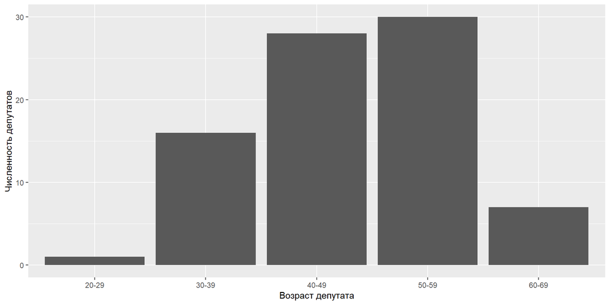

In an interval variation series with unequal intervals it is necessary to determine $M_o$:

1. calculate the frequencies $W$ (%)
2. calculate the density of distribution by dividing the frequency by the value of the corresponding interval: $Z=\frac{W}{i}$.
3. Find the modal interval from the largest density of distribution
4. calculate $M_o$ using the formula:

$$M_o = x_{M_o} + i_{M_o} \frac{Z_{M_o} - Z_{M_o - 1}}{ (Z_{M_o} - Z_{M_o - 1}) + (Z_{M_o} - Z_{M_o + 1}) }$$
In an interval variation series with unequal intervals, $M_o$ can be calculated graphically from the histogram. For this purpose, the corresponding distribution densities are plotted along the ordinate axis instead of frequencies.

## Median, Quartile, Decile

**Median** is the value of a trait that divides the original population into 2 equal parts, with the first half of the population having a trait value less than the median and the second half having a trait value greater than the median.

**Quartile** divides the original population into 4 equal parts. In practice, one calculates the **first (lower)** quartile, which divides the original population in the ratio ¼ : ¾ and the **third (upper)** quartile, which divides the original population in the ratio ¾ : ¼ .

The **Decile** divides the original population into 10 equal parts. For example: the second D divides the original population in the ratio 2/10 : 8/10; the ninth D divides the original population in the ratio 9/10 : 1/10.

In a discrete variation series, to determine $M_e$, quartiles, and deciles, it is necessary to:

1. Calculate the accumulated frequencies.
2. Determine the ordinal number of the unit that divides the original population in the ratio we need.

For example:

- For $M_e$: $n_{M_e} = \frac{\sum f_i}{2}$;
- for the first $Q$: $n_{Q_1} = \frac{\sum f_i}{4}1$;
- for the ninth $D$: $n_{D_9} = \frac{\sum f_i}{10}9$.
3. Using the accumulated frequencies, find the value of the trait that the desired unit of the population has. Example (about families):

| **Number of children** | **Number of families** | **S** |
| --- | --- | --- |
| **Х** | **ƒ** |  |
| **0** | **3** | **3** |
| **1** | **8** | **11** |
| **2** | **4** | **15** |
| **3** | **3** | **18** |
| **4** | **2** | **20** |
| **Total** | **20** | - |

According to the accumulated frequencies, we determine that the 10th unit of the population (10th family) corresponds to the value of the trait equal to 1, so $M_e$ is equal to 1 child. Half of the families have 1 child and no children at all, and the other half have 1 child and more.
$$n_{M_e} = \frac{\sum f_i}{2} \\
n_{Q_3} = \frac{\sum f_i}{4}3 = 15 \\
n_{D_9} = \frac{\sum f_i}{10} 9 = 18$$

Thus we calculated that ¾ of the families (75%) have 2 children or less and 25% of the families have more than 2 children; 90% of the families have 3 children or less and 10% have more than 3 children.

In an interval variation series, to determine the median, quartiles, and deciles, you must:

1. Calculate the cumulative frequencies.
2. Find the ordinal number of the unit that divides the initial population in the ratio we need.
3. According to the accumulated frequencies, find the interval containing the unit of the population we need.
4. The median, quartiles and deciles are calculated using the formulas:
   $$M_e = x_{M_e} + i_{M_e} \frac{ \sum f_i/ 2 - S_{M_e - 1} }{ f_{M_e} }$$
   Where:
- $x_{M_e}$ is the lower boundary of the median interval (an interval containing a unit that divides the entire population into 2 equal parts);
- $i_{M_e}$ is the value of the median interval;
- $S_{M_e - 1}$- the accumulated frequency of the interval preceding the median interval;
- $f_{M_e}$ is the frequency of the median interval.

Example:

| **Age of the deputy (full years) (X)** | **Number of deputies (number of people) (ƒ)** | **S** |
| --- | --- | --- |
| 20-29 | 1 | 1 |
| 30-39 | 16 | 17 |
| 40-49 | 28 | 45 |
| 50-59 | 30 | 75 |
| 60-69 | 7 | 82 |
| **Total:** | **82** |  |

$$n_{M_e} = \frac{\sum f_i}{2} = \frac{82}{2} = 41$$

According to the accumulated frequencies, we determine that the 41st unit of the population is contained in the interval of 40-49 years. This interval is the median interval.

$$M_e = 40 + 9 \frac{ 41 - 17 }{ 28 } = 47,7 (лет)$$

Half of the deputies of the Unity faction are younger than 47.7 years old, the 2nd half are older than 47.7 years old.

In an interval variation series, the median can be calculated graphically by cumulant:

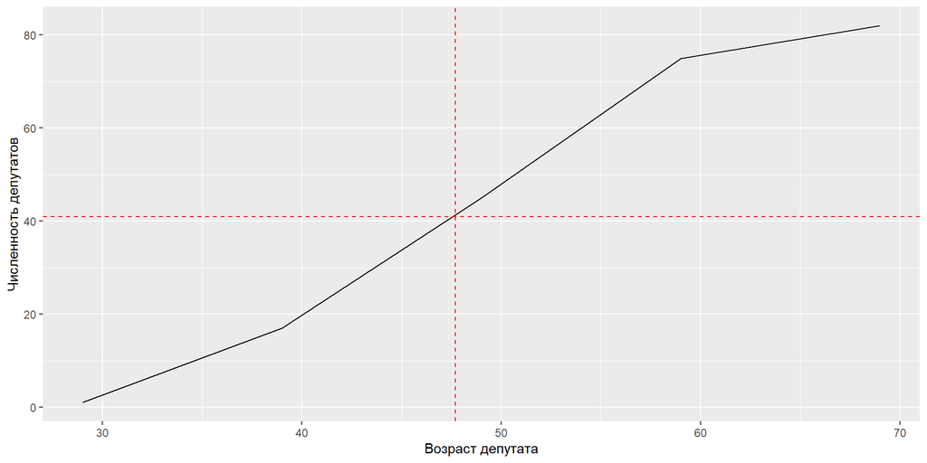

## Quartiles

Quartiles are the values of a trait that divide a ranked population into four equal parts.

The lower quartile ($Q_1$), which separates ¼ of the population with the lowest values of the trait, and the upper quartile ($Q_3$), which separates ¼ of the population with the highest values of the trait.

The middle quartile ($Q_2$) coincides with the median ($M_e$). To calculate quartiles on an interval variation series use the formula:

| **Age of the deputy (full years) (X)** | **Number of deputies (number of people) (ƒ)** | **S** |
| --- | --- | --- |
| 20-29 | 1 | 1 |
| 30-39 | 16 | 17 |
| 40-49 | 28 | 45 |
| 50-59 | 30 | 75 |
| 60-69 | 7 | 82 |
| **Total:** | **82** |  |

$$Q_n = x_{Q_n} + i_{Q_n} \frac{ \sum \frac{f_i}{4}n - S_{Q_n - 1} }{ f_{Q_n} } \\
Q_1 = 40 + 9 \frac{ 20,5 - 17 }{ 28 } = 41,1$$

## Deciles

Variants that divide a ranked series into 10 equal parts; they are calculated using the same scheme as quartiles:

| **Age of the deputy (full years) (X)** | **Number of deputies (number of people) (ƒ)** | **S** |
| --- | --- | --- |
| 20-29 | 1 | 1 |
| 30-39 | 16 | 17 |
| 40-49 | 28 | 45 |
| 50-59 | 30 | 75 |
| 60-69 | 7 | 82 |
| **Total:** | **82** |  |

## Quintiles and percentiles

- Quintiles:
  - Trait values that divide a series into 5 equal parts. They are calculated in the same way as quartiles and deciles.
- Percentiles:
  - A trait value that divides a series into 100 equal parts.